# ashishsa_hw3_p2

We first read the US Arrests Data.

```r
library(ISLR)
library(philentropy)
```

```r
library(ggdendro)
library(dplyr)
library(dendextend)
library(ggplot2)
library(dendextend)
library(kohonen)
data("USArrests")
df1 <- USArrests
head(df1)
```

```
##            Murder Assault UrbanPop Rape
## Alabama      13.2     236       58 21.2
## Alaska       10.0     263       48 44.5
## Arizona       8.1     294       80 31.0
## Arkansas      8.8     190       50 19.5
## California    9.0     276       91 40.6
## Colorado      7.9     204       78 38.7
```

We scale the data first to avoid large values to skew the analysis.

```r
m <- apply(df1,2,mean)
s <- apply(df1,2,sd)
z <- scale(df1,m,s)
```

We perform Heirarchical Clustering using Complete Linkages and Eucledian Distance as a measure of distance.

```r
dist1 <- dist(z,method="euclidean")
hclust1 <- hclust(dist1,method='complete')
```

We create a Dendrogram from the Heirarchical Cluster.

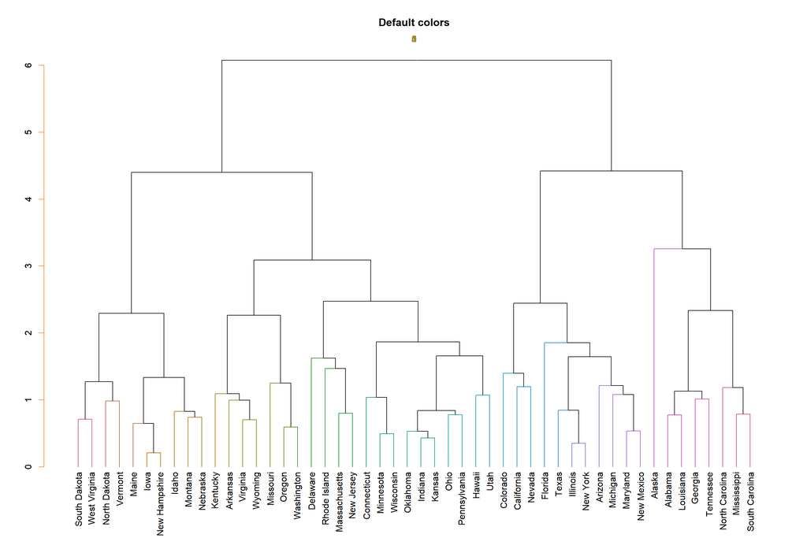

```r
dend1 <- as.dendrogram(hclust1)
dend1 %>% set("branches_k_color") %>%
  plot(main = "Default colors") %>%
  axis(side = 2,col = "#F38630",labels = TRUE) %>%
  mtext(col = "#A38630")
```

As we can observe from the plot the data is partitioned into 4 groups at the same level.

We first try to cluster the Dendrogram into 3 groups and use k=3 to cluster the data into 3 groups.

```r
cutree2 <- cutree(dend1,k=3)
cutree2
```

```
##        Alabama         Alaska        Arizona       Arkansas     California
##              1              1              2              3              2
##       Colorado    Connecticut       Delaware        Florida        Georgia
##              2              3              3              2              1
##         Hawaii          Idaho       Illinois        Indiana           Iowa
##              3              3              2              3              3
##         Kansas       Kentucky      Louisiana          Maine       Maryland
##              3              3              1              3              2
##  Massachusetts       Michigan      Minnesota    Mississippi       Missouri
##              3              2              3              1              3
##        Montana       Nebraska         Nevada  New Hampshire     New Jersey
##              3              3              2              3              3
##     New Mexico       New York North Carolina   North Dakota           Ohio
##              2              2              1              3              3
##       Oklahoma         Oregon   Pennsylvania   Rhode Island South Carolina
##              3              3              3              3              1
##   South Dakota      Tennessee          Texas           Utah        Vermont
##              3              1              2              3              3
##       Virginia     Washington  West Virginia      Wisconsin        Wyoming
##              3              3              3              3              3
```

We now try to cluster the Dendrogram into 3 groups by cutting at an appropriate height. We observe that it clusters into 2 groups at a height of 4.5 and it clusters into 4 groups at a height of 4.4.

```r
cutree1 <- cutree(dend1,h=4.4)
cutree1
```

```
##        Alabama         Alaska        Arizona       Arkansas     California
##              1              1              2              3              2
##       Colorado    Connecticut       Delaware        Florida        Georgia
##              2              3              3              2              1
##         Hawaii          Idaho       Illinois        Indiana           Iowa
##              3              4              2              3              4
##         Kansas       Kentucky      Louisiana          Maine       Maryland
##              3              3              1              4              2
##  Massachusetts       Michigan      Minnesota    Mississippi       Missouri
##              3              2              3              1              3
##        Montana       Nebraska         Nevada  New Hampshire     New Jersey
##              4              4              2              4              3
##     New Mexico       New York North Carolina   North Dakota           Ohio
##              2              2              1              4              3
##       Oklahoma         Oregon   Pennsylvania   Rhode Island South Carolina
##              3              3              3              3              1
##   South Dakota      Tennessee          Texas           Utah        Vermont
##              4              1              2              3              4
##       Virginia     Washington  West Virginia      Wisconsin        Wyoming
##              3              3              4              3              3
```

By manually comparing the values we can infer that the Dendrogram cannot actually be divided into 3 clusters by a clear break a the 2 main groups cut into 4 groups at the same height.

The function k=3 actually divides the cluster into 3 groups by dividing the cluster in a way that 2 groups cluster as 1 group(That is groups 3,4 clusters into group3) and 1 group clusters into 2(That is groups 1,2).

This can be visually confirmed by the following Dendrogram where 2 entires sub group clusters into the Red Group, while 2 more groups are formed that is groups Blue and Green.

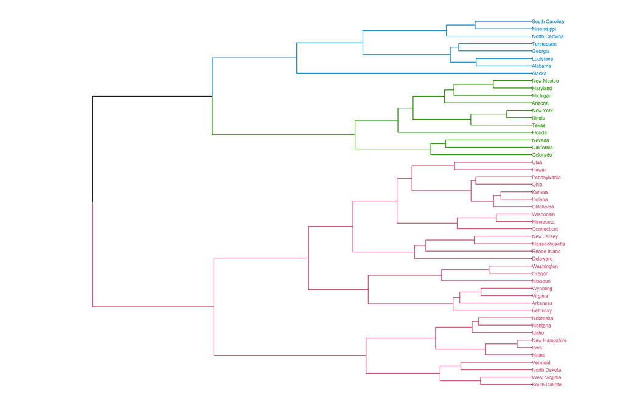

```r
dend <- z %>% dist %>%
  hclust %>% as.dendrogram %>%
  set("branches_k_color", k = 3) %>% set("branches_lwd", 0.7) %>%
  set("labels_cex", 0.6) %>% set("labels_colors", k = 3) %>%
  set("leaves_pch", 19) %>% set("leaves_cex", 0.5)
ggd1 <- as.ggdend(dend)
ggplot(ggd1, horiz = TRUE)
```

```r
training_data <- as.matrix(z)
```

We observe that there are 50 Rows and 4 Columns. So the Number Of Observations can be summed up as:

```r
nr <- nrow(df1)
nc <- ncol(df1)
s_lower <- 0.25*sqrt((nr*nc))
s_lower
```

```
## [1] 3.535534
```

```r
s_upper <- 4*sqrt((nr*nc))
s_upper
```

```
## [1] 56.56854
```

We observe that the nearest square less than 56 is obtaiuned by dim=7. Here the feature map derives the size of 49=>(Xdim=7*Ydim=7). So we create a SOM having x and y dimension as 7.

```r
data_train_matrix <- training_data
som_grid <- somgrid(xdim = 7, ydim=7, topo="hexagonal")
som_model <- som(data_train_matrix,grid=som_grid,rlen=10000)
```

The counts lot gives us the count of the number of states map into the different units.

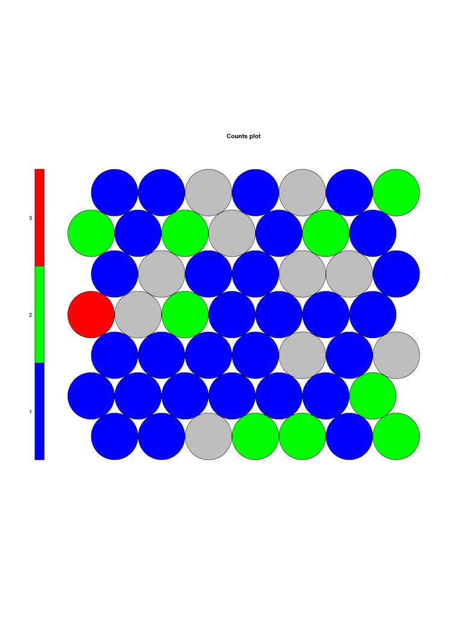

```r
coolBlueHotRed <- function(n,alpha=1){rainbow(n,end=4/6,alpha=alpha)[n:1]}
plot(som_model,type="counts",palette.name=coolBlueHotRed)
```

As we can observe here there are too many states that donot map into different units we reduce the grid size to reduce the number of unnecessary nodes.

```r
som_grid <- somgrid(xdim = 6, ydim=6, topo="hexagonal")
som_model <- som(data_train_matrix,grid=som_grid,rlen=10000)
```

The counts lot gives us the count of the number of states map into the different units.

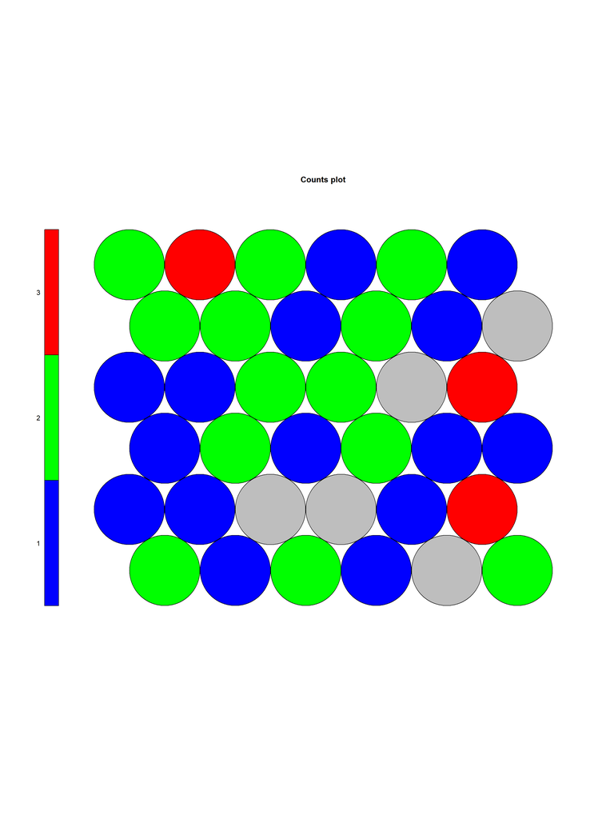

```r
plot(som_model,type="counts",palette.name=coolBlueHotRed)
```

As we can observe there are still units that donot map to any state. We further reduce the size of the SOM Map.

```r
som_grid <- somgrid(xdim = 5, ydim=5, topo="hexagonal")
som_model <- som(data_train_matrix,grid=som_grid,rlen=10000)
```

The counts lot gives us the count of the number of states map into the different units.

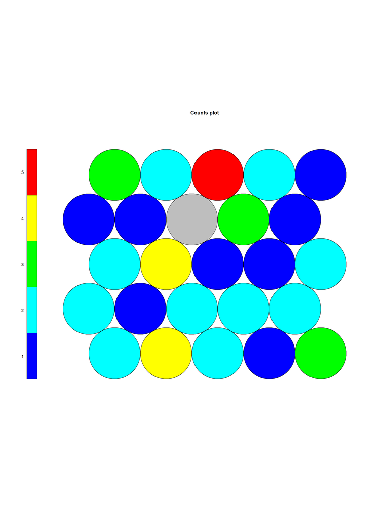

```r
plot(som_model,type="counts",palette.name=coolBlueHotRed)
```

Although the number of states getting mapped to the plot increases there are still instances when there are empty nodes in the map and to avoid it we further reduce the size of the SOM Map.

```r
som_grid <- somgrid(xdim = 4, ydim=4, topo="hexagonal")
som_model <- som(data_train_matrix,grid=som_grid,rlen=10000)
```

The counts lot gives us the count of the number of states map into the different units.

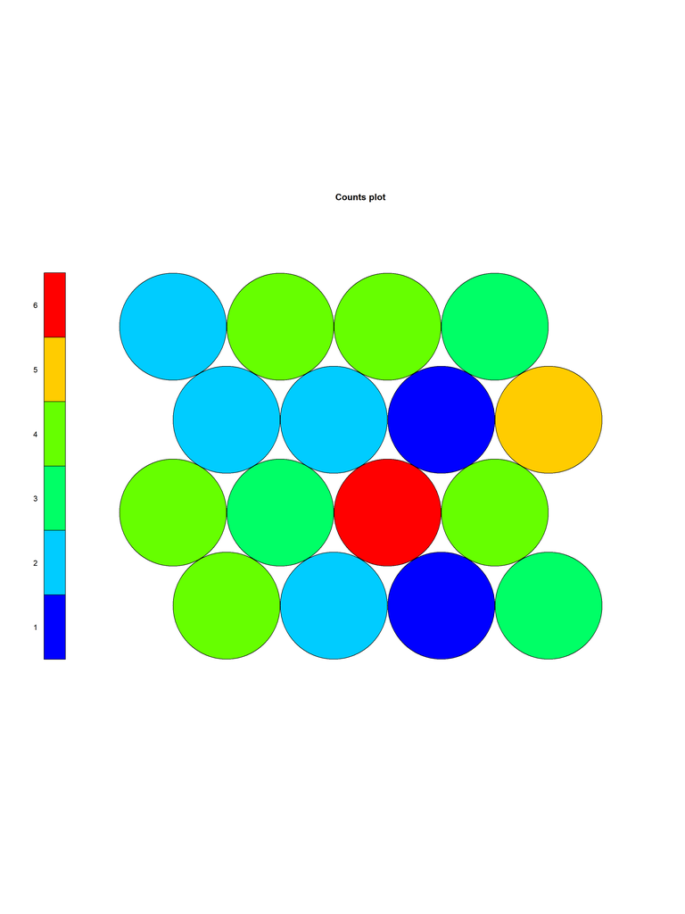

```r
plot(som_model,type="counts",palette.name=coolBlueHotRed)
```

We now plot all this Information onto a Grid. This further reinforcees the information provided by the above Heat Map.

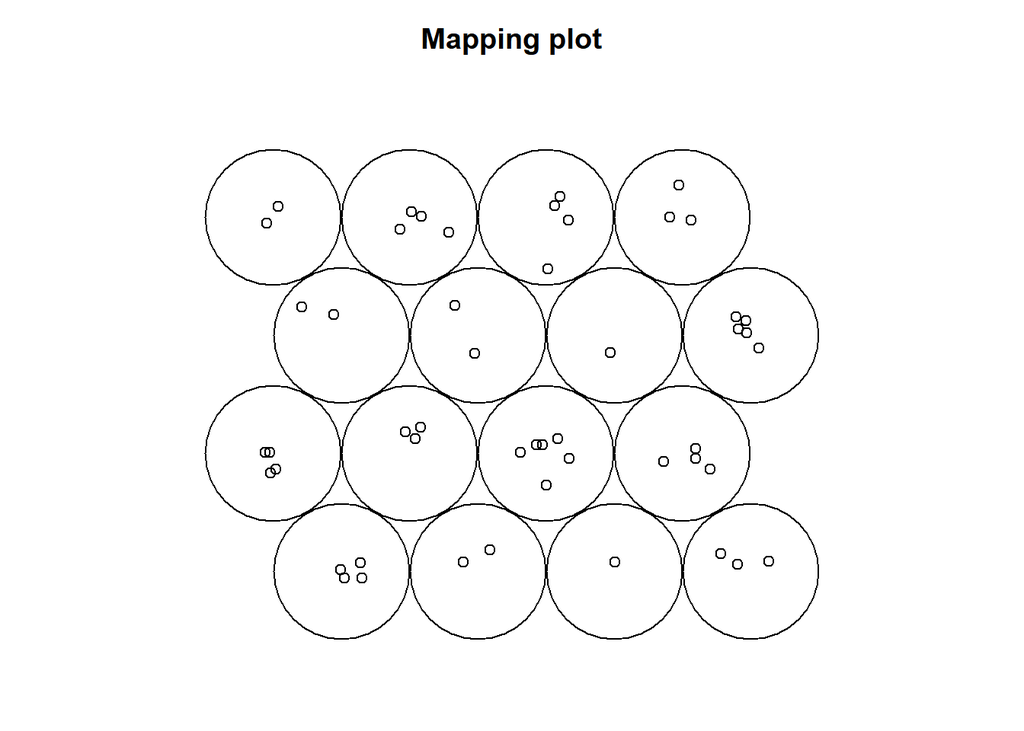

```r
plot(som_model,type="mapping")
```

This gives us the summary of the Self Organization Map.

```r
summary(som_model)
```

```
## SOM of size 4x4 with a hexagonal topology and a bubble neighbourhood function.
## The number of data layers is 1.
## Distance measure(s) used: sumofsquares.
## Training data included: 50 objects.
## Mean distance to the closest unit in the map: 0.418.
```

The codes give us the list of 16 different prototypes and the code books for all of the different prototypes.

```r
som_model$codes
```

```
## [[1]]
##           Murder     Assault    UrbanPop        Rape
## V1  -1.100695934 -1.27856220 -1.73456052 -1.20022050
## V2  -0.004415533 -0.74108152 -0.89936154 -0.52099127
## V3   0.232349382  0.23086801 -1.07359268 -0.18491660
## V4   1.542992944  1.43904034 -1.36513362 -0.26290926
## V5  -1.271568832 -1.30432547 -0.55185387 -1.21735687
## V6  -1.053340241 -0.86664384 -0.34574763 -0.64467175
## V7  -0.225372793 -0.23023615 -0.01642292 -0.30177979
## V8   1.614423354  0.57648167 -0.34099046  0.32209245
## V9  -0.678312238 -0.75361854  0.61513908 -0.87434318
## V10 -0.762954552 -0.22231891  0.30123970  0.70138843
## V11  0.278268232  0.08687549  0.30812248  0.74393700
## V12  0.990421836  1.41209585  0.17801308  1.38016160
## V13 -0.883893399 -0.12257174  1.40821733 -0.92100112
## V14 -0.434032946 -0.75415849  1.09423865 -0.04528998
## V15  0.629297791  0.95138648  1.14773461  0.58432737
## V16  0.504303430  0.87891236  1.19813066  2.24376061
```

We now amalyze the list of all the states and the prototypes that are closest to them.

```r
som_model$unit.classif
```

```
##  [1]  8 12 15  3 16 16  9  7 12  8 14  6 15  7  5  7  2  8  5 12 13 12  6  4 11
## [26]  2  6 16  5 14 12 15  4  1 14  7 10  9 13  4  1  8 15 14  1  7 10  1  5  7
```

```r
head(som_model$changes)
```

```
##            [,1]
## [1,] 0.09217757
## [2,] 0.10087616
## [3,] 0.08616674
## [4,] 0.09132496
## [5,] 0.08250563
## [6,] 0.08132114
```

We observe that the changes start decreasing as we start increasing the number of iterations. A better understanding can be obtained from the Graph which represents the changes in the prototype. The things start converging as we move in the iteration.

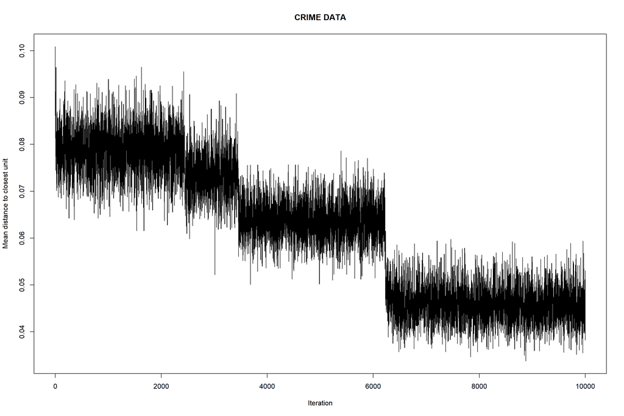

```r
plot(som_model,type="changes",main="CRIME DATA")
```

We now plot the Codes plot which gives us the distribution of various crimes across various nodes.

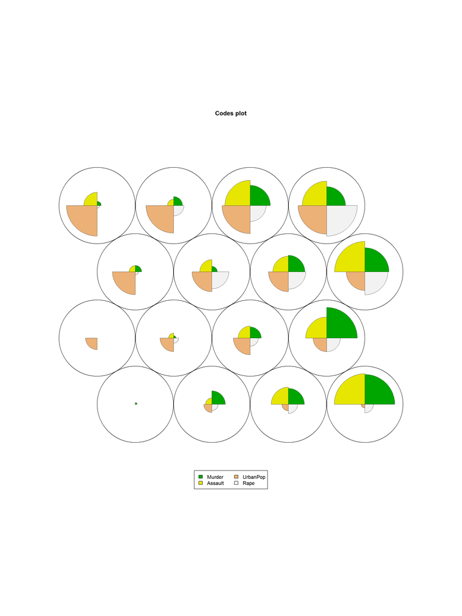

```r
plot(som_model,type = "codes")
```

We now plot the distance to the Neighbours between each states that are plotted into a particular node.

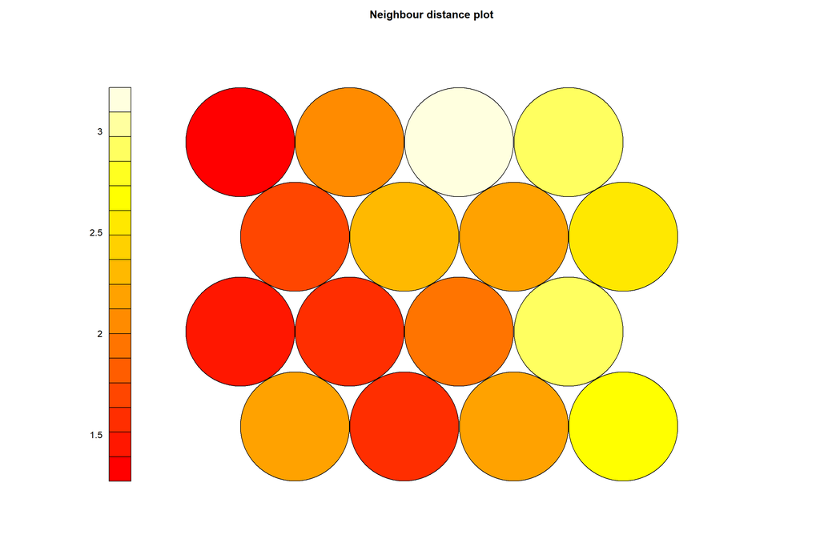

```r
plot(som_model,type="dist.neighbours")
```

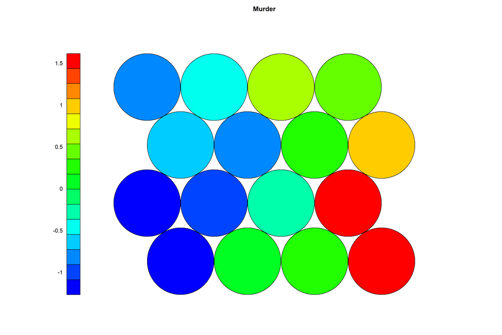

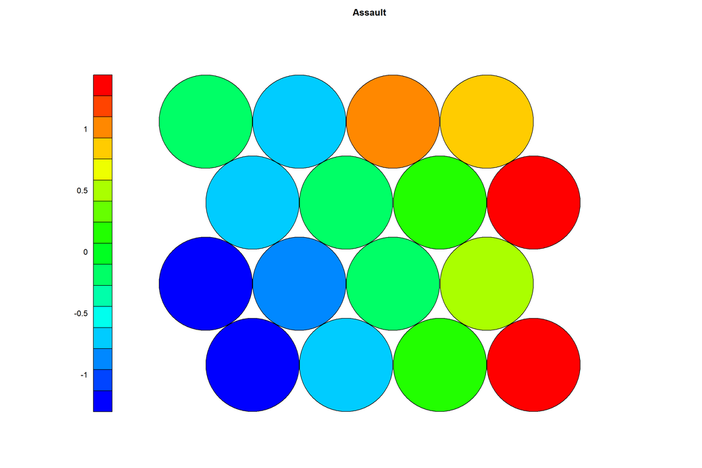

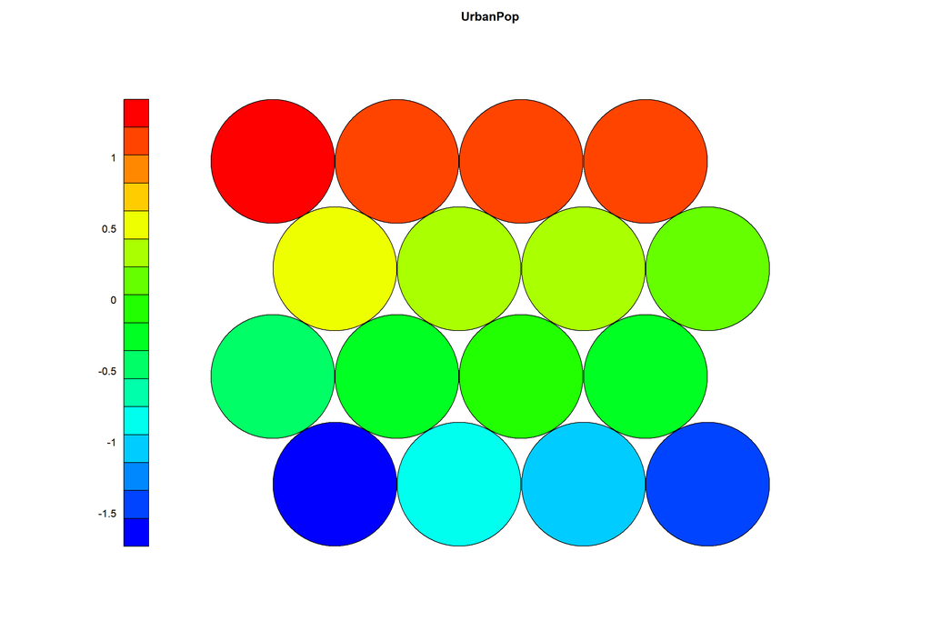

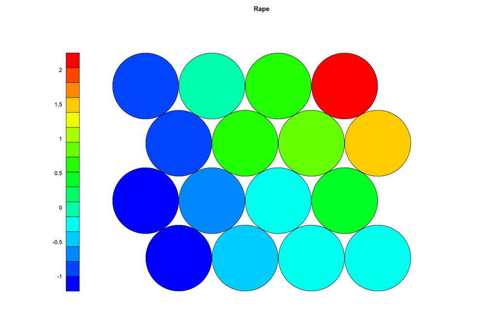

```r
codes <- som_model$codes[[1]]

som_model$data <- data.frame(som_model$data)
for (i in 1:4){
  plot(som_model, type = "property", property = codes[,i], main=names(som_model$data)[i],palette.name=coolBlueHotRed)
  }
```

We find the distance using the SOM_Model codes and observe a clear distinction between the height of the dendrogram between the 2 clusters. This helps us find the point for the cutoff and also helps us easily cluster the dat into 3 distinct groups which was difficult in the case of Plain Heirarchical Clustering using Eucledian Distance.

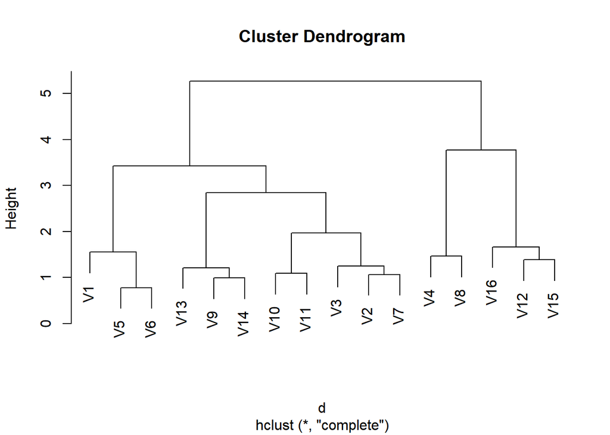

```r
d <- dist(codes)
hc <- hclust(d)
plot(hc)
```

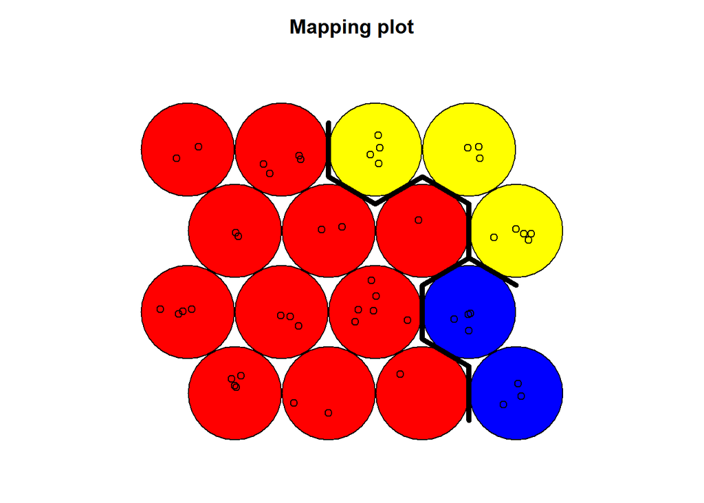

```r
som_cluster <- cutree(hc,h=3.7)
# plot these results:
my_pal <- c("red","blue","yellow")
my_bhcol <- my_pal[som_cluster]

{plot(som_model,type="mapping",col="black",bgcol = my_bhcol)
  add.cluster.boundaries(som_model,som_cluster)}
```